# R Notebook

```r
library(tidyverse)
library(infer)
msleep
```

| name | genus | vore | order | conservation | sleep_total | sleep_rem | sleep_cycle | awake | brainwt | bodywt |
| --- | --- | --- | --- | --- | --- | --- | --- | --- | --- | --- |
| Cheetah | Acinonyx | carni | Carnivora | lc | 12.1 | NA | NA | 11.90 | NA | 50.000 |
| Owl monkey | Aotus | omni | Primates | NA | 17.0 | 1.8 | NA | 7.00 | 0.01550 | 0.480 |
| Mountain beaver | Aplodontia | herbi | Rodentia | nt | 14.4 | 2.4 | NA | 9.60 | NA | 1.350 |
| Greater short-tailed shrew | Blarina | omni | Soricomorpha | lc | 14.9 | 2.3 | 0.1333333 | 9.10 | 0.00029 | 0.019 |
| Cow | Bos | herbi | Artiodactyla | domesticated | 4.0 | 0.7 | 0.6666667 | 20.00 | 0.42300 | 600.000 |
| Three-toed sloth | Bradypus | herbi | Pilosa | NA | 14.4 | 2.2 | 0.7666667 | 9.60 | NA | 3.850 |
| Northern fur seal | Callorhinus | carni | Carnivora | vu | 8.7 | 1.4 | 0.3833333 | 15.30 | NA | 20.490 |
| Vesper mouse | Calomys | NA | Rodentia | NA | 7.0 | NA | NA | 17.00 | NA | 0.045 |
| Dog | Canis | carni | Carnivora | domesticated | 10.1 | 2.9 | 0.3333333 | 13.90 | 0.07000 | 14.000 |
| Roe deer | Capreolus | herbi | Artiodactyla | lc | 3.0 | NA | NA | 21.00 | 0.09820 | 14.800 |

[output cut: 73 more lines]

```r
NA
```

# MVP

## 1.1 Hypothesis testing - practical

### Question 1

Explore the dataset and familiarise yourself with it.

```r
glimpse(msleep)
```

```
Rows: 83
Columns: 11
$ name         <chr> "Cheetah", "Owl monkey", "Mountain beaver", "Greater short-tai…
$ genus        <chr> "Acinonyx", "Aotus", "Aplodontia", "Blarina", "Bos", "Bradypus…
$ vore         <chr> "carni", "omni", "herbi", "omni", "herbi", "herbi", "carni", N…
$ order        <chr> "Carnivora", "Primates", "Rodentia", "Soricomorpha", "Artiodac…
$ conservation <chr> "lc", NA, "nt", "lc", "domesticated", NA, "vu", NA, "domestica…
$ sleep_total  <dbl> 12.1, 17.0, 14.4, 14.9, 4.0, 14.4, 8.7, 7.0, 10.1, 3.0, 5.3, 9…
$ sleep_rem    <dbl> NA, 1.8, 2.4, 2.3, 0.7, 2.2, 1.4, NA, 2.9, NA, 0.6, 0.8, 0.7, …
$ sleep_cycle  <dbl> NA, NA, NA, 0.1333333, 0.6666667, 0.7666667, 0.3833333, NA, 0.…
$ awake        <dbl> 11.9, 7.0, 9.6, 9.1, 20.0, 9.6, 15.3, 17.0, 13.9, 21.0, 18.7, …
$ brainwt      <dbl> NA, 0.01550, NA, 0.00029, 0.42300, NA, NA, NA, 0.07000, 0.0982…
$ bodywt       <dbl> 50.000, 0.480, 1.350, 0.019, 600.000, 3.850, 20.490, 0.045, 14…
```

```r
summary(msleep)
```

```
     name              genus               vore              order
 Length:83          Length:83          Length:83          Length:83
 Class :character   Class :character   Class :character   Class :character
 Mode  :character   Mode  :character   Mode  :character   Mode  :character




 conservation        sleep_total      sleep_rem      sleep_cycle         awake
 Length:83          Min.   : 1.90   Min.   :0.100   Min.   :0.1167   Min.   : 4.10
 Class :character   1st Qu.: 7.85   1st Qu.:0.900   1st Qu.:0.1833   1st Qu.:10.25
 Mode  :character   Median :10.10   Median :1.500   Median :0.3333   Median :13.90
                    Mean   :10.43   Mean   :1.875   Mean   :0.4396   Mean   :13.57
                    3rd Qu.:13.75   3rd Qu.:2.400   3rd Qu.:0.5792   3rd Qu.:16.15
                    Max.   :19.90   Max.   :6.600   Max.   :1.5000   Max.   :22.10
                                    NA's   :22      NA's   :51
    brainwt            bodywt
 Min.   :0.00014   Min.   :   0.005
 1st Qu.:0.00290   1st Qu.:   0.174
 Median :0.01240   Median :   1.670
 Mean   :0.28158   Mean   : 166.136
 3rd Qu.:0.12550   3rd Qu.:  41.750
 Max.   :5.71200   Max.   :6654.000
 NA's   :27
```

### Question 2

Jabberwockies sleep for around 7 hours a night, on average. Perform an appropriate statistical test to determine whether the mean sleep_total in the sampled population of animal types differs from the typical value for jabberwockies.

Determine the hypotheses we want to test:
$$H_0: \mu_{sleep\ jabberwockies} = \mu_{sleep\ of\ all\ animals}\\
H_1: \mu_{sleep\ jabberwockies} \neq \mu_{sleep\ of\ all\ animals}$$

This test will be a two-tailed test.

Set alpha = 0.05

```r
# calculate sample statistic, i.e. mean of total sleep for all animals in sample
sleep_observed_stat <- msleep %>%
  summarise(mean_sleep_total = mean(sleep_total))
```

Create null distribution from the sample data using the bootstrap method and number of reps = 10,000. We will be using the “infer” package workflow to do this.

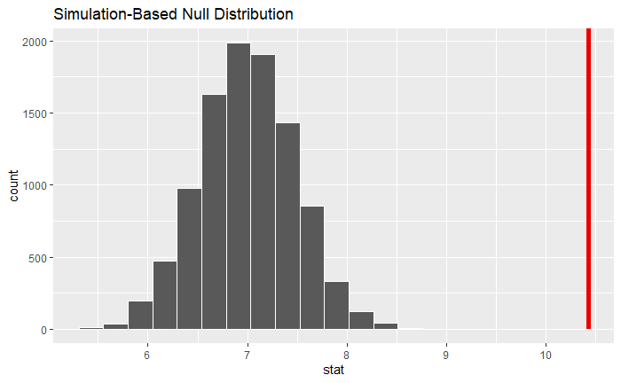

```r
null_distribution_sleep <- msleep %>%
  specify(response = sleep_total) %>%
  hypothesise(null = "point", mu = 7) %>%
  generate(reps = 10000, type = "bootstrap") %>%
  calculate(stat = "mean")

# create histogram of null_distribution
null_distribution_sleep %>%
  visualise() +
  shade_p_value(obs_stat = sleep_observed_stat, direction = "both")
```

```r
p_value <- null_distribution_sleep %>%
  get_p_value(obs_stat = sleep_observed_stat, direction = "both")
```

The p-value is much less (p < 0.001) than the alpha value (0.05) therefore we will *reject* the null hypothesis. This indicates that the average total_sleep is *significantly* different from 7 hours (the average total sleep for jabberwockies).

### Question 3

Perform an appropriate statistical test to determine whether omnivores sleep for significantly longer than herbivores, on average.

Determine the hypotheses we want to test:
$$H_0: \mu_{sleep\ omnivores} = \mu_{sleep\ herbivores}\\
H_1: \mu_{sleep\ omnivores} > \mu_{sleep\ herbivores}$$
Can also be written as:
$$H_0: \mu_{sleep\ omnivores} - \mu_{sleep\ herbivores} = 0\\
H_1: \mu_{sleep\ omnivores} - \mu_{sleep\ herbivores} > 0$$

This test will be a one-tailed test.

Set alpha = 0.05

Firstly, identify the point estimate (sample statistic) that we want to compare, i.e. mean of omnivores total sleep minus the mean of herbivores total sleep.

```r
# filter sample data for only omnivore and herbivore animals
msleep_filtered <- msleep %>%
  filter(vore %in% c("omni", "herbi"))

# calculate sample statistic, i.e. mean of total sleep for all animals in sample
vore_observed_stat <- msleep_filtered %>%
  specify(response = sleep_total, explanatory = vore) %>%
  calculate(stat = "diff in means", order = c("omni", "herbi"))

vore_observed_stat
```

```
Response: sleep_total (numeric)
Explanatory: vore (factor)
```

| stat |
| --- |
| 1.415625 |

Create null distribution from the sample data using the “permute” method and number of reps = 10,000.

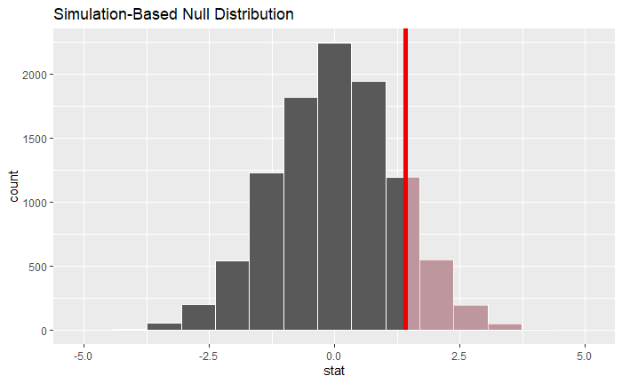

```r
null_distribution_vore <- msleep_filtered %>%
  specify(response = sleep_total, explanatory = vore) %>%
  hypothesise(null = "independence") %>%
  generate(reps = 10000, type = "permute") %>%
  calculate(stat = "diff in means", order = c("omni", "herbi"))

# create histogram of null_distribution
null_distribution_vore %>%
  visualise() +
  shade_p_value(obs_stat = vore_observed_stat, direction = "right")
```

```r
p_value <- null_distribution_vore %>%
  get_p_value(obs_stat = vore_observed_stat, direction = "right")

p_value
```

| p_value |
| --- |
| 0.122 |

```r
NA
```

### Question 4

Perform an appropriate statistical test to determine whether the proportion of domesticated animal types in the population of animal types is greater than 5%.

Determine the hypotheses we want to test:
$$H_0: \pi_{domesticated} = 5\%\\
H_1: \pi_{domesticated} > 5\%$$

This test will be a one-tailed test.

Set alpha = 0.05

```r
# create column specifying if animal is domesticated, change NA to FALSE
msleep_dom <- msleep %>%
  mutate(is_domesticated = conservation == "domesticated",
         is_domesticated = coalesce(is_domesticated, FALSE),
         .after = conservation)

# calculate sample statistic, i.e. proportion of domesticated animals
dom_observed_stat <- msleep_dom %>%
  specify(response = is_domesticated, success = "TRUE") %>%
  calculate(stat = "prop")

dom_observed_stat
```

```
Response: is_domesticated (factor)
```

| stat |
| --- |
| 0.1204819 |

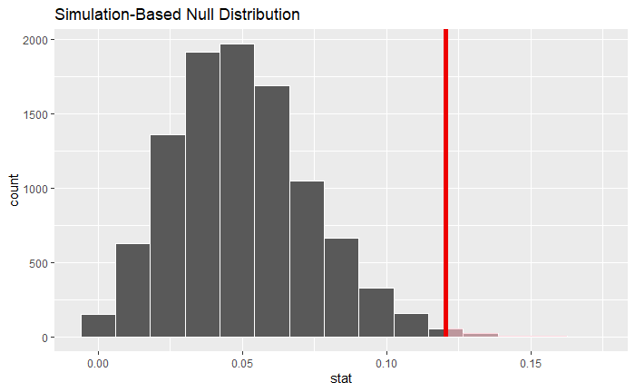

```r
null_distribution_dom <- msleep_dom %>%
  specify(response = is_domesticated, success = "TRUE") %>%
  hypothesise(null = "point", p = 0.05) %>%
  generate(reps = 10000, type = "draw") %>%
  calculate(stat = "prop")

# create histogram of null_distribution
null_distribution_dom %>%
  visualise() +
  shade_p_value(obs_stat = dom_observed_stat, direction = "right")
```

```r
p_value <- null_distribution_dom %>%
  get_p_value(obs_stat = dom_observed_stat, direction = "right")

p_value
```

| p_value |
| --- |
| 0.009 |

```r
NA
```

## 1.2 Hypothesis testing - Defining the Hypothesis

For the following three business problems write out:

- What kind of test you would use
- H0 and Ha in both mathematical notation and in words.
- Also state the method you would use to generate the null distribution (bootstrap, permutation or draw).

### Question 1

Test type: One-sample type - proportions - one-tailed

Hypotheses:

Null hypothesis: The number of people in the town who are aware of the coffee shop is less than 40%.

The alternative hypothesis: The number of people in the town who are aware of the coffee shop is greater than or equal to 40%

$$H_0 : \pi_{aware} < 40\% \\
H_1 : \pi_{aware} \geq 40\%$$

Null distribution method: “draw”

### Question 2

Test type: Two sample test - difference in proportions

Hypotheses:

Null hypothesis: The CTR of Group A and Group B are the same, i.e. the location of the banner on the webpage shows no change in the CTR.

The alternative hypothesis: The CTR of Group A and Group B are not the same, i.e. the location of the banner on the webpage does show a change in the CTR.

Null distribution method: “permute”

### Question 3

Test type: one sample test - two-tailed - mean

Hypotheses:

Null Hypothesis: Car part width is equal to 145mm

Alternative Hypothesis: Car part width is not equal to 145mm

$$H_0 : \mu_{width} = 145mm \\
H_1 : \mu_{width} \neq 145mm$$

Null distribution method: “bootstrap”

## 1.3 Hypothesis Testing - Interpreting the results

### Question 1.

Coffee shop problem. Significance level: 0.05, calculated p-value: 0.07

Since the p-value is greater than the significance we should *reject the alternative hypothesis* which states that the average proportion of people in the town who are aware of the coffee shop is greater than or equal to 40% and *fail to reject* the null hypothesis, i.e. less than 40% of people are aware of the coffee shop.

### Question 2.

Website company problem. Significance level: 0.01, p-value: 0.006

Since the p-value is less than the significance level we must *reject* the null hypothesis since we have evidence to support the alternative hypothesis. In this case we have evidence to support that the change of banner location has had a statistically significant impact on the CTR.

### Question 3.

Manufacturing company problem. Significance level: 0.05, p-value: 0.55

Since the p-value is greater than the significance level we should *fail to reject* the null hypothesis which states that the manufacturing company is achieving the quality assurance target of 145mm for that car part, i.e. there is no statistical significant deviation from the 145mm average target.

# EXTENSION

## 2.1 Market Basket Analysis

```r
library(janitor)
transactions <- read_csv("data/online_retail_subset.csv") %>%
  clean_names()
```

For the first section we are interested in the purchase of two particular items:

item A - ‘HEART OF WICKER SMALL’ (StockCode 22469) item B - ‘LARGE CAKE TOWEL PINK SPOTS’ (StockCode 21110)

### Question 1

Calculate the support for item A (this will be the support for a single item)

```r
# filter data for stock code and distinct invoice_no
num_transactions_A <- transactions %>%
  filter(stock_code == 22469) %>%
  distinct(invoice_no, stock_code) %>%
  summarise(prob_A = n())

# calculate number of total distinct invoices
total_transactions <- transactions %>%
  distinct(invoice_no) %>%
  summarise(n())

sup_A <- num_transactions_A / total_transactions

sup_A
```

| prob_A |
| --- |
| 0.07681366 |

```r
NA
```

### Question 2

Calculate the support and confidence for rule (A→B).

```r
# find the number of invoices that have both products A and B
num_A_and_B <- transactions %>%
  filter(stock_code %in% c(22469, 21110)) %>%
  group_by(invoice_no) %>%
  summarise(num_prod = n_distinct(stock_code)) %>%
  filter(num_prod == 2) %>%
  summarise(num_A_and_B = n())

# calculate sup(A -> B)
sup_A_and_B <- num_A_and_B / total_transactions

sup_A_and_B
```

| num_A_and_B |
| --- |
| 0.003556188 |

```r
  # filter(invoice_no %in% c(536520, 536592, 537144, 537773, 538071, 538349, 538524),
  #        stock_code %in% c(22469, 21110))
```

```r
# conf(A -> B) = sup(A -> B) / sup(A)
conf_A_and_B <- sup_A_and_B / sup_A
conf_A_and_B
```

| num_A_and_B |
| --- |
| 0.0462963 |

```r
NA
```

### Question 3.

Calculate the lift for (A → B)

```r
num_transactions_B <- transactions %>%
  filter(stock_code == 21110 ) %>%
  distinct(invoice_no, stock_code) %>%
  summarise(prob_B = n())

sup_B <- num_transactions_B / total_transactions

sup_B
```

| prob_B |
| --- |
| 0.009957326 |

```r
NA
```

```r
lift_A_and_B <- sup_A_and_B / (sup_A * sup_B)

lift_A_and_B
```

| num_A_and_B |
| --- |
| 4.649471 |

```r
NA
```

# Apriori Algorithm

```r
library(arules)
library(arulesViz)
transactions_reformat <- transactions %>%
  select(invoice_no, description) %>%
  na.omit()

write_csv(transactions_reformat, "transactions_reformat.csv")

apriori_format <- read.transactions("transactions_reformat.csv", format = "single", sep = ",", header = TRUE, cols = c("invoice_no", "description"))
```

```r
inspect(head(apriori_format))
```

```
    items                                                        transactionID
[1] {CREAM CUPID HEARTS COAT HANGER,
     GLASS STAR FROSTED T-LIGHT HOLDER,
     KNITTED UNION FLAG HOT WATER BOTTLE,
     RED WOOLLY HOTTIE WHITE HEART.,
     SET 7 BABUSHKA NESTING BOXES,
     WHITE HANGING HEART T-LIGHT HOLDER,
     WHITE METAL LANTERN}                                               536365
[2] {HAND WARMER RED POLKA DOT,
     HAND WARMER UNION JACK}                                            536366
[3] {ASSORTED COLOUR BIRD ORNAMENT,
     BOX OF 6 ASSORTED COLOUR TEASPOONS,
     BOX OF VINTAGE ALPHABET BLOCKS,
     BOX OF VINTAGE JIGSAW BLOCKS,
     DOORMAT NEW ENGLAND,
     FELTCRAFT PRINCESS CHARLOTTE DOLL,
     HOME BUILDING BLOCK WORD,
     IVORY KNITTED MUG COSY,
     LOVE BUILDING BLOCK WORD,
     POPPYS PLAYHOUSE BEDROOM
536367,POPPYS PLAYHOUSE KITCHEN,
     RECIPE BOX WITH METAL HEART}                                       536367
[4] {BLUE COAT RACK PARIS FASHION,
     JAM MAKING SET WITH JARS,
     RED COAT RACK PARIS FASHION,
     YELLOW COAT RACK PARIS FASHION}                                    536368
[5] {BATH BUILDING BLOCK WORD}                                          536369
[6] {ALARM CLOCK BAKELIKE GREEN,
     ALARM CLOCK BAKELIKE PINK,
     ALARM CLOCK BAKELIKE RED,
     CHARLOTTE BAG DOLLY GIRL DESIGN,
     CIRCUS PARADE LUNCH BOX,
     INFLATABLE POLITICAL GLOBE,
     LUNCH BOX I LOVE LONDON,
     MINI JIGSAW CIRCUS PARADE,
     MINI JIGSAW SPACEBOY,
     MINI PAINT SET VINTAGE,
     PANDA AND BUNNIES STICKER SHEET,
     POSTAGE,
     RED TOADSTOOL LED NIGHT LIGHT,
     ROUND SNACK BOXES SET OF4 WOODLAND,
     SET 2 TEA TOWELS I LOVE LONDON,
     SET/2 RED RETROSPOT TEA TOWELS,
     SPACEBOY LUNCH BOX,
     STARS GIFT TAPE,
     VINTAGE HEADS AND TAILS CARD GAME,
     VINTAGE SEASIDE JIGSAW PUZZLES}                                    536370
```

```r
transactions %>%
  distinct(description)
```

| description |
| --- |
| WHITE HANGING HEART T-LIGHT HOLDER |
| WHITE METAL LANTERN |
| CREAM CUPID HEARTS COAT HANGER |
| KNITTED UNION FLAG HOT WATER BOTTLE |
| RED WOOLLY HOTTIE WHITE HEART. |
| SET 7 BABUSHKA NESTING BOXES |
| GLASS STAR FROSTED T-LIGHT HOLDER |
| HAND WARMER UNION JACK |
| HAND WARMER RED POLKA DOT |
| ASSORTED COLOUR BIRD ORNAMENT |

[output cut: 990 more lines]

```r
NA
```

```r
# get the rules

rules <- apriori(apriori_format, parameter = list(supp = 0.02, conf = 0.6,
                                                  minlen = 3),
                 control = list(verbose = F))

# rules <- sort(rules, by="confidence", decreasing=TRUE)

inspect(rules[])
```

```
    lhs                               rhs                              support confidence   coverage      lift count
[1] {HAND WARMER BABUSHKA DESIGN,
     HOT WATER BOTTLE BABUSHKA}    => {HAND WARMER BIRD DESIGN}     0.02035623  0.6153846 0.03307888  8.339523    16
[2] {HAND WARMER BABUSHKA DESIGN,
     HAND WARMER BIRD DESIGN}      => {HOT WATER BOTTLE BABUSHKA}   0.02035623  0.6666667 0.03053435 10.076923    16
[3] {HAND WARMER BIRD DESIGN,
     HOT WATER BOTTLE BABUSHKA}    => {HAND WARMER BABUSHKA DESIGN} 0.02035623  0.7272727 0.02798982 10.585859    16
```

```r
library(arulesViz)

plot(rules, method="graph", engine = "interactive")
```

[output not shown]